[figure not shown]

INTERNATIONAL FINANCE · TEACHING DESIGN

# 国际金融

西部外贸企业的汇率风险识别与管理

从合同现金流出发，用情景、计算与AI核验，形成负责任的专业判断。

进入本讲学习 ↗

情景实验 ↗AI核验 ↗课堂测验 ↗

**90**分钟**2**学时**6**道测验

THE CASE · 核心案例

40 万美元

三个月后，同日美元净应收敞口

合同应收**100万美元**

可匹配应付**60万美元**

企业与金额为课堂案例设定。先核对条件，再决定管理安排。

COURSE PATH / 90 MIN

**01**订单与教学任务**02**风险与匹配条件**03**净敞口与计量**04**套保与情景实验**05**AI核验与预算决策**06**测验迁移与教案

先读事实，再识别敞口。  
先定目标，再比较方案。  
AI建议须经独立核验。

完整教案与任务单 ↗资料与来源 ↗

CHAPTER01

## 从订单进入管理任务

服务实体经济的价值，在具体合同、计算和审慎决策中体现。

### 授课教师

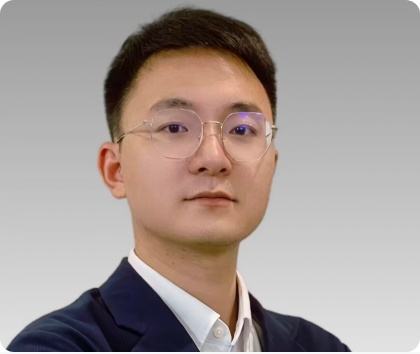

#### 王奇

四川大学商学院副教授、硕士生导师  
科技金融四川省重点实验室固定研究员

研究领域：AI Agent、中国经济结构转型。

以合同现金流、情景比较和证据核验组织本讲学习，连接国际金融知识、财务计算与数字工具。

qiwangphd@scu.edu.cn

### 本讲目标与业务任务

企业希望按期履约，保持人民币预算的可预期性。学生需要识别净敞口、匹配远期方向，在给定情景下比较三种比例，再提交有依据、有边界的管理建议。

| 维度 | 学习成果 | 证据 |
| --- | --- | --- |
| 知识 | 风险分类、净额、自然对冲和远期安排 | Q1—Q4与计算表 |
| 能力 | 情景比较、AI核验和预算决策 | 核验单、决策单与迁移任务 |
| 素养 | 诚信履约、规范计算和决策责任 | 假设、证据与复核条件 |

### 回信精神融入具体专业行动

以2026年9月28日习近平总书记给四川大学全体师生的回信为依据，将服务国家战略和西部发展落实为帮助实体企业稳健经营的专业任务；将交叉融合落实为经济分析、财务计算和数字工具共同支持的证据核验。

诚信与敬业体现在不隐藏不利情景、不编造数据或AI运行记录，风险责任体现在说明条件、边界和复核要求。课堂评价依据学生的专业行动，不以口号数量代替学习成效。

依据：教材及回信官方材料，详见资料区[1—3]。

### 90分钟的教学安排

[figure not shown]

教学方法、学习任务与目标证据逐项对应。

| 时段 | 环节 | 时长 |
| --- | --- | --- |
| 0—5 | 情境导入与价值连接 | 5分钟 |
| 5—12 | 学情诊断与报价回顾 | 7分钟 |
| 12—25 | 风险识别与敞口计量 | 13分钟 |
| 25—40 | 自然对冲与远期套保 | 15分钟 |
| 40—45 | 第一学时检验 | 5分钟 |
| 45—57 | AI建议核验 | 12分钟 |
| 57—72 | 小组情景决策 | 15分钟 |
| 72—82 | 展示与教师点拨 | 10分钟 |
| 82—90 | 课末测验与迁移 | 8分钟 |

45分钟处分为两个学时；课间休息另计。课前与课后任务不计入90分钟。

CHAPTER02

## 识别风险与匹配条件

先把合同改写为谁、何时、收付哪种货币、多少金额。

### 先界定风险对象

[figure not shown]

本例首先是交易风险。外币报表折算与未来竞争力变化具有不同对象和时间范围，不能把一笔远期交易解释为消除企业全部外汇风险。

### 四项条件决定能否直接匹配

| 条件 | 本例事实 | 不满足时 |
| --- | --- | --- |
| 主体 | 同一企业 | 不直接假定受限或跨法人资金可自由轧差 |
| 币种 | 同为美元 | 分别分桶 |
| 日期 | 三个月后同日 | 评估资金衔接和交割安排 |
| 确定性 | 收付金额确定 | 重新审查预测订单与超额套保 |

[figure not shown]

即使金额相同，若应付提前而应收延后，仍需解决资金衔接；不能仅用100−60得出一个可立即完全对冲的金额。

CHAPTER03

## 从应收总额到净敞口

所有比例以自然匹配后的40万美元为基数，所有人民币结果以万元列示。

### 订单、收付与净额

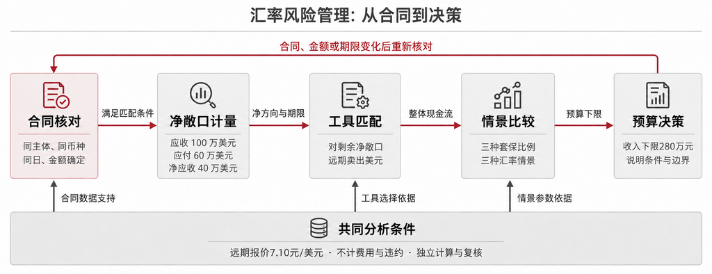

由合同条件、净敞口到预算决策的完整逻辑。

[figure not shown]

报价为元人民币/美元。e从7.10降到6.80，表示每美元可兑换的人民币减少，即人民币升值；这会降低美元净应收的人民币折算收入，但不会自动减少合同规定的美元金额。

### 统一计量口径

| 到期汇率 | 净收入 | 读数 |
| --- | --- | --- |
| 6.80 | 272万元 | 美元换得的人民币较少 |
| 7.10 | 284万元 | 与远期报价相同 |
| 7.40 | 296万元 | 美元换得的人民币较多 |

R表示净外币收付款折算金额，不是企业利润。三个情景不表示预测，也不附加概率。

CHAPTER04

## 比较管理安排与情景结果

不套保、部分套保和完全套保的差异，应结合事前目标与整体业务评价。

### 从自然对冲到远期结汇

[figure not shown]

60万美元应付先与同日应收匹配，剩余40万美元为净应收。企业在到期时有美元、需要人民币，因此匹配方向是远期卖出美元。期限与金额应与确定业务相对应，避免对100万美元总应收重复套保。

[figure not shown]

曲线是汇率与折算金额的情景关系，不表示真实时间路径。

### 用同一组参数独立复算

INTERACTIVE LAB · 情景实验

先使用默认案例比较三种比例，再改变金额、比例、报价和预算。若净方向转为应付，结果自动切换为付款成本与远期买入美元；若日期或确定性不符，暂停简化套保计算。

应收美元（万美元）应付美元（万美元）收付款日期金额与业务确定性远期汇率 F到期汇率 e净敞口套保比例 h收入下限（万元）

合同简单差额

当前h与到期e下的金额

期限应与确定业务匹配

区间固定为6.80—7.40

紫色虚线为当前比例；红色虚线为预算要求。图形不表示汇率预测。

| 到期汇率 | 0%套保 | 50%套保 | 100%套保 |
| --- | --- | --- | --- |

表中金额单位为万元人民币，使用当前净金额与远期汇率。

**展开共同假设与结果边界**

同一企业，同一币种，同一收付款日；100万美元应收与60万美元应付均确定。

远期结汇F＝7.10元/美元；套保比例h以自然匹配后的40万美元净敞口为基数。

不计费用、保证金占用、融资成本与违约；不讨论提前交割、税费和会计确认。

到期汇率6.80、7.10、7.40为情景设定，不代表预测；收入指净外币收付款折算后的人民币金额，不等于企业利润。

输入不是实际市场数据。零净敞口时无剩余远期交易需求；超出预算可达范围时明确显示无可行比例。

CHAPTER05

## AI核验与负责任的预算决策

工具提供待核建议，计算提供可复查结果，学生必须说明依据与责任边界。

### AI建议须经独立审查

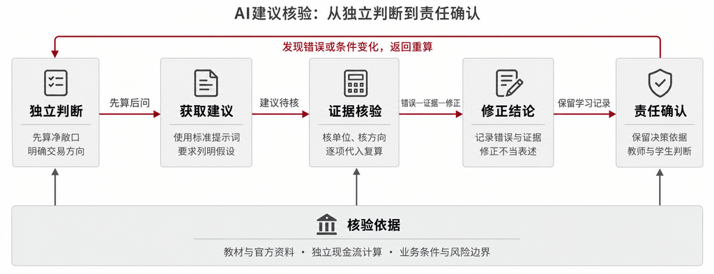

独立判断、证据核验与反馈重算的逻辑路径。

[figure not shown]

先个人复核3分钟，再同伴核对5分钟，教师归纳4分钟。以下文本有意设置错误，属于预置核验练习，不代表实时AI调用或专业结论。若联网使用工具，另行记录实际工具、时间、提示词与输出。

标准提示词

#### 待核验文本 1

公司应按100万美元全部套保，不需要考虑60万美元应付款。

错误证据或复算修正

**完成核验后查看参考**

**错误：**漏计可自然匹配的应付款，套保基数错误。

**证据：**同主体、同币种、同日期的净应收为100−60＝40万美元。

**修正：**先确认应付可匹配，再对剩余40万美元确定套保比例。

#### 待核验文本 2

收到美元后担心人民币升值，应远期买入40万美元。

错误证据或复算修正

**完成核验后查看参考**

**错误：**把交易方向反置。

**证据：**人民币升值使每美元兑换的人民币减少；净应收对应美元多头。

**修正：**为确定净应收办理期限匹配的远期卖出美元。

#### 待核验文本 3

AI判断三个月后一定到7.40，因此不套保不会有预算风险。

错误证据或复算修正

**完成核验后查看参考**

**错误：**把预测当作确定事实，并据此否认风险。

**证据：**情景不是概率或预测；6.80时不套保收入仅272万元。

**修正：**比较多个情景，以预算下限和风险承受能力决定方案。

#### 待核验文本 4

100%远期套保可以保证企业利润最高，并消除所有风险。

错误证据或复算修正

**完成核验后查看参考**

**错误：**把折算收入锁定夸大为利润最大和风险清零。

**证据：**远期锁定本笔净收入284万元；7.40时不套保为296万元，企业还有其他经营风险。

**修正：**说明稳定性与机会收益的取舍，并保留信用、履约和流动性边界。

记录仅保存在本机浏览器；导出文件不会提交到服务器。

### 小组决策：由预算要求检验方案

在三个给定情景下，要求人民币净收入不低于280万元。每组提交净敞口、远期方向与期限、情景表、未采纳方案及理由、风险边界与复核触发条件。两组各展示3分钟，教师综合点评4分钟，其余小组提交书面成果。

| 方案 | 最低收入 | 达到下限 |
| --- | --- | --- |
| 不套保 | 272万元 | 否 |
| 50%套保 | 278万元 | 否 |
| 100%套保 | 284万元 | 是 |

[figure not shown]

连续比例推导为可选提高任务。该下限只针对给定区间、确定金额和简化成本条件，不能推广为任意未来汇率下的保证。

### 用证据评价方案

| 维度 | 分值 | 证据 |
| --- | --- | --- |
| 专业正确 | 12 | 净额、方向、金额、日期、单位与公式 |
| 证据与推理 | 9 | 完整情景表及预算解释 |
| 风险边界 | 6 | 假设、不能保证的结果及复核条件 |
| 表达 | 3 | 简洁结论、清晰图表和记录 |

AI核验20分另按四类错误各5分记录：识别2分、证据2分、修正1分。只写“AI错了”不能获得证据分。

CHAPTER06

## 测验、迁移与持续改进

用个人结果检验掌握程度，再把识险、匹配、比较和核验的方法迁移到新情境。

### 六道四选一测验

#### Q1 / 课前诊断

采用“元人民币/美元”报价，汇率由7.10降至6.80。在本讲条件下，正确的判断是。A. 人民币贬值，美元净应收折算收入增加B. 人民币升值，美元净应收折算收入减少C. 美元升值，美元净应收折算收入减少D. 人民币升值，美元净应收金额自动减少

**答案与逐项解析**

正确答案：B

- **A.** 本币/外币报价下降表示人民币升值，方向判断反了。
- **B.** 每美元换得的人民币减少；在美元净应收不变时，人民币收入减少。
- **C.** 报价下降表示美元相对人民币贬值，而非升值。
- **D.** 汇率改变折算金额，不自动改变合同规定的美元金额。

#### Q2 / 课前诊断

企业已签订合同，三个月后确定收取一笔美元货款，其人民币折算金额随汇率变化。这首先属于。A. 境外报表折算风险B. 国内商品库存数量风险C. 外汇交易风险D. 人民币现金存款利率风险

**答案与逐项解析**

正确答案：C

- **A.** 报表折算风险主要涉及外币财务报表的折算，与本题中已确定但尚未结算的外币收款无直接关系。
- **B.** 本题没有商品库存数量变化，不能用它解释汇率引起的折算变化。
- **C.** 已确定、尚未结算的外币收付款面临汇率变动，属于交易风险。
- **D.** 题干未涉及人民币存款利率变化。

#### Q3 / 课中检验

企业同日确定收取100万美元、支付60万美元，无其他外汇业务。自然匹配后的美元净敞口是。A. 净应收40万美元B. 净应收100万美元C. 净应付60万美元D. 净应收160万美元

**答案与逐项解析**

正确答案：A

- **A.** 相同主体、币种和日期下，100−60＝40万美元，为净应收。
- **B.** 只计应收，漏掉可匹配的同日应付。
- **C.** 忽略了金额更大的应收，将净方向判断反了。
- **D.** 把流入与流出直接相加，得到的不是净敞口。

#### Q4 / 课中检验

对Q3中已确定的净敞口进行100%远期套保，且期限匹配，企业应办理哪项交易？（ ）A. 远期买入100万美元B. 远期卖出100万美元C. 远期买入40万美元D. 远期卖出40万美元

**答案与逐项解析**

正确答案：D

- **A.** 美元净应收需要卖出美元；买入100万美元会扩大美元多头。
- **B.** 自然匹配后仅剩40万美元；卖出100万美元可能造成60万美元超额套保。
- **C.** 买入美元适合匹配净应付，本题方向相反。
- **D.** 按剩余40万美元净应收、同到期日远期卖出美元，方向与规模匹配。

#### Q5 / 课末测验

企业有40万美元净应收，其中50%按7.10元/美元的汇率远期结汇，其余在到期时按6.80元/美元结汇。忽略费用，人民币净收入是多少？（ ）。A. 272万元B. 278万元C. 284万元D. 296万元

**答案与逐项解析**

正确答案：B

- **A.** 272＝40×6.80，对应完全不套保。
- **B.** 278＝20×7.10＋20×6.80，单位为万元人民币。
- **C.** 284＝40×7.10，对应100%远期套保。
- **D.** 296＝40×7.40，是另一情景下不套保的结果。

#### Q6 / 课末测验

在本讲净应收金额确定且忽略费用的条件下，下列对100%远期套保的评价中，最恰当的是（ ）。A. 保证所有情景下收入最高B. 保证企业全部经营利润不变C. 锁定该笔净敞口的折算收入，但不保证事后收入最高D. 只要AI预测人民币贬值，就应取消已确定的套保方案

**答案与逐项解析**

正确答案：C

- **A.** 当到期汇率高于7.10，不套保的折算收入可能更高。
- **B.** 套保只能管理本笔交易的汇率不确定性，不能消除生产、信用等全部经营风险。
- **C.** 在上述条件成立时锁定284万元；评价应结合预算目标和整体业务，不应只以事后最高收益为标准。
- **D.** 预测不能替代风险目标；经营变化需要复核敞口、授权和调整成本。

### 课后迁移：进口企业的美元净应付

企业三个月后同日确定支付80万美元、收取30万美元；远期购汇7.12元/美元。比较6.90、7.12、7.40下的0%、50%、100%套保，判断能否将净付款成本控制在360万元内。先个人完成，再查看参考。

[figure not shown]

**教师参考与计算过程**

净应付50万美元，方向为远期买入美元。

| 到期汇率 | 0% | 50% | 100% |
| --- | --- | --- | --- |
| 6.90 | 345 | 350.5 | 356 |
| 7.12 | 356 | 356 | 356 |
| 7.40 | 370 | 363 | 356 |

单位为万元人民币；下限仍依赖给定区间，不是所有未来情形保证。迁移任务20分：净额方向5、计算6、预算5、边界来源4。

### 全过程学习与课后反思

[figure not shown]

| 任务 | 分值 |
| --- | --- |
| 课前诊断与准备 | 10 |
| 个人课堂计算与测验 | 20 |
| AI核验记录 | 20 |
| 小组决策单 | 30 |
| 课后迁移 | 20 |

记录真实作答、核验单、决策单与匿名反馈，按“事实—原因—调整—下次验证”改进。实际成绩、专家评价和成效数据在授课后据实补充，不预写为已经发生的事实。

### 完整教案与可填写任务单

**01 西部外贸企业的汇率风险识别与管理**

稳健经营 服务实体

本科课程示范教案与配套教学材料

INTERNATIONAL FINANCE / TEACHING DESIGN / 2026

以真实业务逻辑组织课堂，借助情景分析形成可复核的专业判断。

本讲以西部装备制造企业的美元收付款为贯穿案例，将风险识别、自然对冲、远期结汇与AI建议核验连为完整学习任务。学生最终提交有计算、有依据、有风险边界的管理建议，理解金融支持实体经营的具体方式。

90分钟 · 两学时 · 六道四选一测验

授课教师 王奇 四川大学商学院

qiwangphd@scu.edu.cn

**02 课程信息与教材分析**

本讲选取教材第九章第一节的内容，作为一个完整教学单元申报；教学时长为90分钟，内容涵盖外汇风险识别、净敞口计量与远期管理，旨在衔接理论学习和企业决策。

#### 课程信息

| 项目 | 内容 |
| --- | --- |
| 课程与教学单元 | 国际金融 第九章第一节 外汇风险管理 |
| 授课对象与学时 | 商学院本科生；两学时90分钟，课间休息另计 |
| 课程前后衔接 | 前置：汇率标价、即期与远期；后续：综合风险管理与企业决策 |
| 教材与教学资源 | 《国际金融》第二版；原创知识图、单选题、HTML与AI核验单 |

#### 课程简介与单元作用

国际金融研究开放经济中的跨境资金活动及其管理。本讲将前期学过的汇率报价与远期交易应用于企业已确定的外币收付款业务，使学生不仅能够读懂报价、完成单项计算，还能够识别业务条件、比较方案并解释决策依据。

#### 教材分析

教材第九章第一节提供外汇风险分类及管理的基础框架。本讲保留对交易风险、折算风险和经济风险的辨析，重点讲解交易风险、自然匹配与远期套保。以同一组参数贯穿净敞口计算、交易方向判断、情景结果比较和预算决策，避免工具介绍与实际业务脱节。[1]

期权定价、复杂套保会计和汇率预测不作为本讲必修内容；连续套保比例作为可选提高任务。数字工具用于显示情景关系，不能替代对合同主体、币种、日期和确定性的核对。

#### 服务西部实体经营的案例定位

案例设定为西部装备制造企业同日收100万美元、付60万美元。学生须按合同和预算提出可复核建议，理解金融服务实体经济的具体方式。企业与金额为课堂案例设定，不对应真实企业的业绩记录。

**03 01 教学目标与评价证据**

本讲以知识、能力、素养三类成果组织教学；每一目标均对应可观察的学生产出。目标达成以个人计算、核验记录和小组方案中的可观察表现为依据。

| 目标 | 完成本讲后学生能够 | 达成证据 |
| --- | --- | --- |
| 知识K1 | 正确区分交易、折算与经济风险；说明本例首先属于交易风险 | Q2及风险分类说明 |
| 知识K2 | 按主体、币种、日期和确定性识别40万美元净应收 | Q3、个人净敞口计算 |
| 知识K3 | 说明自然对冲与远期结汇的关系；正确选择卖出方向和规模 | Q4、现金流匹配图 |
| 能力A1 | 计算三种比例、三个情景的人民币净收入；核对单位 | Q5、情景计算表 |
| 能力A2 | 识别并修正待核验建议中的四类错误，逐项给出证据 | AI核验单 |
| 能力A3 | 根据预算下限提出方案并解释稳定性与机会收益的取舍 | 小组决策单、课后迁移 |
| 素养V1 | 说明合同履约、规范流程和审慎使用AI的责任边界 | 决策前提与复核安排 |

图1 目标与评价证据对应关系。

#### 达成判断与补救

知识与计算任务以关键步骤正确为基本达成；AI核验至少识别三类错误并给出可复算依据。预算建议必须同时包含敞口、工具方向、金额、日期及风险边界。若前测显示学生普遍混淆报价方向，则先增加单位换算演示，再相应减少拓展性比例推导的时间。

**04 02 教学思想与学情分析**

学生已具备一定的概念基础和计算能力，前期学习过《金融衍生工具》《基础会计》等课程，但在企业合同阅读、整体现金流评价和AI结果核验方面经验不足。

#### 教学思想

本讲将习近平给四川大学全体师生的回信精神落实到课堂中，并将其转化为三项具体任务：一是结合国家战略和西部发展需要分析经营案例，提出既服务发展、又能控制风险的稳健方案；二是把经济分析与财务计算结合起来，用数据判断方案是否可行，而不是只作定性表态；三是对AI给出的建议进行核验，检查其数据来源、计算依据和适用条件，不能直接照搬。学生先独立判断，再通过小组讨论相互质证、修正结论。

#### 学情与可观察的学习障碍

| 学习基础或障碍 | 课堂可见表现 | 教学应对 |
| --- | --- | --- |
| 标价法易混淆 | 把e下降误判为人民币贬值 | 先读单位“元/美元”，再解释每美元换得的人民币 |
| 总额与净额混淆 | 按100万美元套保，漏掉应付60万美元 | 建立收付清单，用图示抵消后保留40万美元 |
| 工具方向易反置 | 对净应收远期买入美元 | 由到期现金流出发：有美元需换人民币，对应卖出美元 |
| 事后收益导向 | 7.40时不套保收入高，便认定套保失败 | 提前给出预算下限，比较最不利情景与收入区间 |
| AI依赖与核验薄弱 | 因表述流畅而直接采纳错误结论 | 先个人计算，再按错误、证据、修正提交记录 |

#### 分层与包容

基础组使用已给定表格完成代入；进阶组解释50%方案的斜率与残余敞口；提高组求给定区间内的最低套保比例。所有学生均完成核心计算与风险边界说明，不以提高题替代基本目标。

**05 03 教学内容与重难点**

本讲先界定风险对象，再建立收付款清单。交易风险、折算风险和经济风险的作用范围不同，不能用同一笔远期交易管理所有类型的风险。

图2 三类风险及本讲观察范围。依据教材第九章第一节整理。

#### 业务清单的四项核对

| 核对项 | 本例条件 | 条件变化时的处理 |
| --- | --- | --- |
| 主体 | 同一企业可统一管理的现金流 | 不同法人或受限资金不能直接假定可自由轧差 |
| 币种 | 收付均为美元 | 不同币种需分别归集，不能直接相减 |
| 日期 | 均为三个月后同日结算 | 日期错配须分析融资、交割或滚动安排 |
| 确定性 | 收款与付款金额均已确定 | 预测订单变化时，须复核是否出现超额套保 |

#### 教学重点及突破方式

重点是净敞口与交易安排的匹配，以及按事前目标评价套保效果。先画现金流，再按主体、币种、日期和确定性分桶；用共同参数完成三种比例、三个情景的同口径比较。

#### 教学难点及突破方式

难点是把“收入稳定”与“事后收入最高”区分开。先读情景曲线，再引入280万元下限，让学生用预算、机会收益和条件边界解释选择；不以预测汇率代替管理目标。

**06 04 教学方法与整体路径**

教学方法、教学内容和教学目标逐项对应，保证各环节具有明确的学习任务与可观察的达成证据。

图3 教学方法、学习任务与目标证据的对应关系。图形与任务结构为本讲原创。

#### 方法选择及其适用环节

| 教学方式 | 具体安排与理由 |
| --- | --- |
| 启发式讲授 | 从“每美元换多少人民币”和到期现金流出发，纠正标价、净额与工具方向的误解。 |
| 探究式核验 | 先完成个人计算，再审查预置的AI建议，提交错误识别结果、核验证据和修正意见，避免因表述流畅而直接采纳建议。 |
| 协作与非标准答案任务 | 围绕预算比较离散方案，允许提出其他比例，但须给出条件、计算与风险边界。 |
| 课前准备与课后迁移 | 用Q1—Q2诊断前置知识；课后迁移到美元净应付，检验方法能否跨情境使用。 |

完整路径：课前诊断 → 课堂识险与计算 → AI核验与小组决策 → 课末测验 → 课后迁移与真实反馈。两学时各45分钟，课堂总计90分钟。

**07 05 教学过程 第一学时**

0—45分钟：统一基本概念和计算口径，完成合同核对、净敞口计量和远期交易匹配，形成完整的计算流程。

[output not shown]

#### 典型师生对话与反馈

学生若说“收入100万美元，所以卖出100万美元”，教师提示：“同日应支付的60万美元用哪笔资金支付？”学生先在清单上圈出可匹配部分，再重新写净敞口。教师随后说明：若盲目卖出100万美元，可能形成60万美元超额套保。

第一学时结束应保留三项板书：四项核对、N＝40万美元、远期卖出美元。学生没有掌握方向时，第二学时优先完成基本核验，不追加复杂比例推导。

**08 05 教学过程 第二学时**

45—90分钟：在正确计算的基础上开展AI核验与预算决策。学生要用可复核的证据说明判断，而不能只给出一个套保比例。

| 教学环节 | 用时 | 教学内容与师生活动 | 设计意图 |
| --- | --- | --- | --- |
| AI建议核验 | 45—5712分钟 | 先个人复核3分钟，再同伴核对5分钟，最后教师归纳4分钟；依据AI核验单逐项标注错误、证据和修正。 | 将生成式AI使用转化为可评估的审查过程；检查是否出现“用AI证明AI”。 |
| 小组情景决策 | 57—7215分钟 | 小组使用配套HTML网页比较三个情景和三种套保比例，以人民币净收入不低于280万元为目标形成决策单。基础组代入计算，提高组探索区间内h下限。 | 以预算约束引导学生分析和评价方案；每组至少记录一个不采纳的方案及其原因。 |
| 展示与教师点拨 | 72—8210分钟 | 抽取两组各3分钟展示，教师4分钟综合点评；其余组提交书面成果。点评按正确性、证据、边界、表达展开。 | 通过公开论证促进同伴学习；不要求每组都进行现场汇报，以确保活动能在规定时间内完成。 |
| 课末测验与迁移 | 82—908分钟 | 4分钟完成Q5、Q6，2分钟归纳，2分钟布置进口企业迁移任务与退出反馈。 | 用个人结果检验目标达成，并将方法迁移到净应付情境。 |

#### 小组角色与产出

建议每组4—6人，分别承担合同核对、计算、AI核验和汇报记录任务，人数较少时合并角色。提交一页决策单：净敞口、工具方向与期限、情景表、预算结论、风险边界与复核触发条件。

#### 预算讨论的教师参考结论

在0%、50%、100%三个离散方案中，只有100%套保在给定三个情景下均达到280万元下限。允许学生提出其他比例，但必须说明适用条件并验证计算结果；若要求到期汇率在6.80—7.40区间内的收入均不低于280万元，则最不利情景为6.80，由此可得h至少为2/3。该结论不构成对任意未来汇率情景的保证。

#### 扫码或点击二维码进入互动任务

| 情景实验调整比例，动态比较结果 | AI核验记录错误、证据与修正 | 测验迁移完成单选与进口案例 |
| --- | --- | --- |

**09 06 AI赋能与算例核验**

先用独立计算建立正确基准，再核验建议。预置文本仅用于核验练习，不作为真实AI工具的运行日志。联网使用时记录真实工具、时间、提示词和输出。

N = 100 − 60 = 40 （万美元）

Rₕ(e) = 40[h × 7.10 + (1 − h)e] （万元人民币）

| 到期汇率 | 0%套保 | 50%套保 | 100%套保 |
| --- | --- | --- | --- |
| 6.80 | 272 | 278 | 284 |
| 7.10 | 284 | 284 | 284 |
| 7.40 | 296 | 290 | 284 |

共同条件：同主体、同币种、同日且金额确定，忽略费用、融资、保证金占用、违约与税费。R为外币净收款的人民币折算金额，不等于企业利润。50%套保在6.80下为20×7.10＋20×6.80＝278万元。

图4 先独立判断，再核验与修正；完整提示词与填写表见附件二。

| 核验焦点 | 必须给出的证据 |
| --- | --- |
| 基数与方向 | 100−60＝40万美元净应收，应远期卖出美元。 |
| 预测与预算 | 6.80情景下，不套保的人民币净收入仅为272万元，低于280万元的预算下限，因此不能凭汇率预测认定不存在预算风险。 |
| 锁定与边界 | 完全套保可将本笔净应收的人民币折算收入锁定为284万元；到期汇率为7.40时，不套保的收入为296万元，因此完全套保不保证事后收入最高或企业利润最大。 |

每类错误5分：识别2分、证据2分、修正1分，四类合计20分。可使用学校允许的联网AI工具；HTML仅用于确定性计算和可视化，不属于AI模型。

**10 07 全过程考核与评价**

本讲评价分为个人学习70分和小组决策30分，形成贯穿课前、课中和课后的连续评价证据，不改变整门课程原有的总评比例。

| 任务 | 分值 | 具体计分与证据 |
| --- | --- | --- |
| 课前诊断与准备 | 10 | Q1、Q2各3分；合同清单准备4分。诊断后允许订正，保留初答与订正。 |
| 个人课堂计算与测验 | 20 | Q3、Q4各4分，Q5、Q6各3分；个人情景计算表6分。 |
| AI核验记录 | 20 | 四类错误各5分：识别2、证据2、修正1。 |
| 小组决策单 | 30 | 按专业正确性40%、证据与推理30%、风险边界20%、表达10%折算。 |
| 课后进口企业迁移 | 20 | 净额与方向5分；计算6分；预算结论5分；边界与来源4分。 |

#### 小组决策量规

| 维度及分值 | 充分达成 | 需改进 |
| --- | --- | --- |
| 专业正确 12分 | 净额、方向、金额、日期、公式与单位一致 | 漏项、反向或单位混乱；按错误严重程度扣分 |
| 证据与推理 9分 | 提供完整情景表，并按预算比较方案 | 只报比例，缺计算或用预测替代依据 |
| 风险边界 6分 | 说明期限、确定性、费用及经营变化的复核要求 | 声称保证利润、风险清零或未列条件 |
| 表达 3分 | 结论简洁，图表可复算，角色和记录清楚 | 结论与证据不对应或读者无法复算 |

#### 价值与专业评价相互支撑

诚信体现在不隐藏不利情景、不编造AI记录；敬业体现在按合同与预算开展审慎分析；责任体现在说明调整条件和授权边界。评分应以上述行为证据为依据，不能以口号多少代替对专业表现的评价。

**11 08 教学反思与实施保障**

本讲围绕报价方向、净敞口、工具匹配与预算解释设置观察点，以课堂作答、计算表和小组方案诊断学习困难，并据此调整教学节奏。

| 可能出现的问题 | 课堂调整 | 授课后核验依据 |
| --- | --- | --- |
| 报价方向误判较多 | 增加“1美元换多少人民币”的单位解释，先暂缓h推导 | Q1初答与订正分布、学生解释记录 |
| 净额或方向仍不牢固 | 返回合同清单与远期现金流图，减少提高题 | Q3、Q4错因与个人计算表 |
| 小组用预测代替预算 | 要求提交最低收入和不采纳方案的证据 | 决策单的情景完整性、预算解释 |
| AI核验仅停留在口头指出错误 | 教师示范一条“错误—证据—修正”，再让学生独立写其余 | 核验单证据栏的得分与引用质量 |
| 网络或设备不可用 | 使用离线HTML与纸质情景表，发放预置文本 | 任务完成情况及后备方案使用记录 |

#### 设计中值得保留的做法

一组共同参数贯穿净额、套保、AI核验和预算决策，减少重复读题负担；个人先算、小组再议，防止少数学生包办；由现金流推导工具方向，再用情景比较检验方案，便于追踪错误来源。通过个人计算、同伴讨论与方案展示相互印证，形成可追踪的学习证据。

#### 课后反思的写作路径

按“观察到的事实—可能原因—采取的调整—下一次验证”记录。优先分析学生为什么漏掉应付款、为什么把预测当依据、为什么用事后最高收入评价套保。结合匿名反馈与作答记录分析共性错因，形成下一轮教学调整依据。

#### 后续改进的触发条件

若净额与方向仍出现同类错误，下次优先增加分桶练习；若计算正确但预算解释不足，增加两个目标不同的企业情景；若AI核验缺少证据，则缩短待核验的AI文本，强化来源定位与手算对照。教学改进应依据学生的具体错误、任务表现和评价结果展开。

**12 配套课件展示与资料依据**

通过配套课件中的净敞口图与情景曲线，展示教案在课堂中的具体实施方式。完整主课件共26页，独立单选题共14页，二者均采用与本教案一致的案例参数和评价依据。

配套课件截图：从合同总额到净敞口，再以情景曲线解释稳定性与机会收益。

#### 材料来源与使用范围

[1] 范小云、陈平主编：《国际金融》第二版，高等教育出版社，2019，第九章第一节，第256—266页。

[2] 习近平给四川大学全体师生的回信，2026年9月28日；教育部网站2026年9月29日刊载。https://www.moe.gov.cn/jyb_xwfb/moe_176/202609/t20260929_1452614.html

[3] 生态环境部转载新华社报道，2026年9月29日，可交叉核验回信主要表述。https://www.mee.gov.cn/ywdt/szyw/202609/t20260929_1175502.shtml

[4] 国家外汇管理局企业汇率风险管理服务小组：《企业汇率风险管理指引（2024年版）》。https://www.safe.gov.cn/hubei/file/file/20250627/70d7b5f7233246e89c92c8483bc446d9.pdf

[5] 国家外汇管理局四川省分局公开材料：《汇率风险中性基础知识》，2022年。用于风险中性概念，不作为当期业务规则。https://www.safe.gov.cn/sichuan/file/file/20220601/9ecf217f2bcd4812b32f41f44939e1b5.pdf

**13 附件一 合同与净敞口任务单**

学生姓名________ 学号________ 小组________ 日期________

案例：西部某装备制造企业将在三个月后的同一天收取100万美元、支付60万美元，两笔金额均已确定。两笔现金流属于同一企业、币种均为美元。远期结汇报价7.10元/美元。完成核对后，再选择是否以及如何套保。

| 核对项 | 我核实的事实 | 若事实变化需补充的信息 |
| --- | --- | --- |
| 主体 |  |  |
| 币种 |  |  |
| 日期 |  |  |
| 确定性 |  |  |

#### 独立计算与解释

净敞口算式：________________________________________________

净方向、币种与日期：________________________________________

合适的远期交易方向及理由：__________________________________

| 到期汇率 | 0%套保 | 50%套保 | 100%套保 |
| --- | --- | --- | --- |
| 6.80 |  |  |  |
| 7.10 |  |  |  |
| 7.40 |  |  |  |

我采用的金额单位：________ 套保比例的计算基数：________

同日匹配条件不成立时，为什么不能直接沿用40万美元这一净敞口计算结果？________________________________________________________________________________________________________________________________

作答要求：先个人完成，再参与讨论；计算表需保留至少一行代入过程。

**14 附件二 AI建议核验单**

姓名________ 小组________ 使用方式：联网工具 / 预置文本（圈选）

实际联网使用时填写：工具名称________ 日期时间________；附真实输出。使用预置文本时无需虚填工具或运行时间。

| 待核验文本 | 错误与复算证据 | 修正 |
| --- | --- | --- |
| 1. 公司应按100万美元全部套保，不需要考虑60万美元应付款。 |  |  |
| 2. 收到美元后担心人民币升值，应远期买入40万美元。 |  |  |
| 3. AI判断三个月后一定到7.40，因此不套保不会有预算风险。 |  |  |
| 4. 100%远期套保可以保证企业利润最高，并消除所有风险。 |  |  |

#### 可复制的标准提示词

你是企业财务分析助手。企业将在三个月后的同一天收取100万美元、支付60万美元，两笔金额均已确定，远期结汇7.10元/美元。请先核对主体、币种、日期与确定性，再计算净敞口，比较0%、50%、100%套保在6.80、7.10、7.40下的人民币净收入。以万元人民币为单位列示公式和计算过程，说明交易方向、假设、预算目标以及结论的适用条件和局限。不预测汇率，不承诺利润最大化；对不确定的内容，先列出需要核实的信息。

每项5分：识别2分、证据2分、修正1分。正文第9页及教师答案提供核验锚点。预置文本包含有意设置的错误，不代表专业结论或实时AI输出。

**15 附件三 小组风险管理决策单**

小组________ 合同核对________ 计算________ 核验________ 汇报记录________

任务：在本讲给定情景下，使三个月后的人民币净收入不低于280万元。比较0%、50%、100%三个方案，写出可以复核的建议。

| 决策要素 | 小组填写 |
| --- | --- |
| 净敞口及核对条件 |  |
| 远期方向、金额与交割日 |  |
| 所选方案与人民币结果 |  |
| 未采纳的方案及原因 |  |
| 采用的证据或数据来源 |  |
| 不能保证的结果与其他风险 |  |
| 经营变化后的复核触发条件 |  |

#### 简短决策陈述

我们建议____________________________________________________原因与预算依据______________________________________________在以下条件下需要重新评估____________________________________

#### 提高任务 可选

若允许h在0—1间连续变化，要求在e∈[6.80,7.40]区间内均达到280万元，请求h下限，并说明为何这不构成任意未来汇率下的保证。________________________________________________________________________________________________________________________________

评分30分：专业正确12分、证据推理9分、风险边界6分、表达3分。两组现场展示，其余提交书面记录。

**16 附件四 课前与课中四选一测验**

每题只有一个正确答案。Q1—Q2课前完成并订正，Q3—Q4在第一学时末独立完成。

#### Q1 课前诊断

采用“元人民币/美元”报价，汇率由7.10降至6.80。在本讲条件下，正确的判断是。

A. 人民币贬值，美元净应收折算收入增加

B. 人民币升值，美元净应收折算收入减少

C. 美元升值，美元净应收折算收入减少

D. 人民币升值，美元净应收金额自动减少

#### Q2 课前诊断

企业已签订合同，三个月后确定收取一笔美元货款，其人民币折算金额随汇率变化。这首先属于。

A. 境外报表折算风险

B. 国内商品库存数量风险

C. 外汇交易风险

D. 人民币现金存款利率风险

#### Q3 课中检验

企业同日确定收取100万美元、支付60万美元，无其他外汇业务。自然匹配后的美元净敞口是。

A. 净应收40万美元

B. 净应收100万美元

C. 净应付60万美元

D. 净应收160万美元

#### Q4 课中检验

对Q3中已确定的净敞口进行100%远期套保，且期限匹配，企业应办理哪项交易？（ ）

A. 远期买入100万美元

B. 远期卖出100万美元

C. 远期买入40万美元

D. 远期卖出40万美元

初答：Q1____ Q2____ Q3____ Q4____ 订正：Q1____ Q2____保留原答案；订正时，写明在汇率方向、风险分类、净额计算或交易安排方面的具体错误。

**17 附件五 课末测验与迁移作业**

课末Q5—Q6个人独立完成。课后任务先判断净方向，再选择交易方向，不照搬出口企业的远期卖出安排。

#### Q5 课末测验

企业有40万美元净应收，其中50%按7.10元/美元的汇率远期结汇，其余在到期时按6.80元/美元结汇。忽略费用，人民币净收入是多少？（ ）。

A. 272万元

B. 278万元

C. 284万元

D. 296万元

#### Q6 课末测验

在本讲净应收金额确定且忽略费用的条件下，下列对100%远期套保的评价中，最恰当的是（ ）。

A. 保证所有情景下收入最高

B. 保证企业全部经营利润不变

C. 锁定该笔净敞口的折算收入，但不保证事后收入最高

D. 只要AI预测人民币贬值，就应取消已确定的套保方案

#### 课后任务 进口企业的美元净应付

企业三个月后同日确定支付80万美元、收取30万美元。远期购汇7.12元/美元。到期汇率为6.90、7.12、7.40，忽略与主案例相同的成本及违约因素。企业希望人民币净付款成本在这些情景下不超过360万元。

提交一页分析：①按四项条件核对净敞口；②确定远期方向；③列出0%、50%、100%套保成本；④选择满足预算的方案；⑤说明边界和经营变化后的复核要求。提高任务：求给定区间内最低h。

提交要求：计算过程与结论可复算；如使用AI，附实际提示词与核验记录，不以AI回答代替个人解释。建议课后48小时内提交，实际时间由教师发布。

**18 附件六 教师参考答案与错因**

正确答案依次为B、C、A、D、B、C。解析用于讲评与反馈；正式测验时不提前展示。

Q1 答案 B

A. 本币/外币报价下降表示人民币升值，方向判断反了。

B. 每美元换得的人民币减少；在美元净应收不变时，人民币收入减少。

C. 报价下降表示美元相对人民币贬值，而非升值。

D. 汇率改变折算金额，不自动改变合同规定的美元金额。

Q2 答案 C

A. 报表折算风险主要涉及外币财务报表的折算，与本题中已确定但尚未结算的外币收款无直接关系。

B. 本题没有商品库存数量变化，不能用它解释汇率引起的折算变化。

C. 已确定、尚未结算的外币收付款面临汇率变动，属于交易风险。

D. 题干未涉及人民币存款利率变化。

Q3 答案 A

A. 相同主体、币种和日期下，100−60＝40万美元，为净应收。

B. 只计应收，漏掉可匹配的同日应付。

C. 忽略了金额更大的应收，将净方向判断反了。

D. 把流入与流出直接相加，得到的不是净敞口。

Q4 答案 D

A. 美元净应收需要卖出美元；买入100万美元会扩大美元多头。

B. 自然匹配后仅剩40万美元；卖出100万美元可能造成60万美元超额套保。

C. 买入美元适合匹配净应付，本题方向相反。

D. 按剩余40万美元净应收、同到期日远期卖出美元，方向与规模匹配。

Q5 答案 B

A. 272＝40×6.80，对应完全不套保。

B. 278＝20×7.10＋20×6.80，单位为万元人民币。

C. 284＝40×7.10，对应100%远期套保。

D. 296＝40×7.40，是另一情景下不套保的结果。

Q6 答案 C

A. 当到期汇率高于7.10，不套保的折算收入可能更高。

B. 套保只能管理本笔交易的汇率不确定性，不能消除生产、信用等全部经营风险。

C. 在上述条件成立时锁定284万元；评价应结合预算目标和整体业务，不应只以事后最高收益为标准。

D. 预测不能替代风险目标；经营变化需要复核敞口、授权和调整成本。

**19 附件七 评分记录与迁移参考**

按本讲量规记录成绩，保留个体与小组证据。评分记录与学生个人信息仅在授权教学环境中使用。

| 评价项目 | 满分 | 实得 | 主要证据或反馈 |
| --- | --- | --- | --- |
| 课前诊断与准备 | 10 |  |  |
| 课堂计算与测验 | 20 |  |  |
| AI核验记录 | 20 |  |  |
| 小组决策 | 30 |  |  |
| 课后迁移 | 20 |  |  |
| 合计 | 100 |  |  |

#### 迁移任务教师参考

净应付为80−30＝50万美元，对应远期买入美元。成本函数Cₕ(e)＝50[h×7.12＋(1−h)e]，单位为万元人民币。

| 到期汇率 | 0%套保 | 50%套保 | 100%套保 |
| --- | --- | --- | --- |
| 6.90 | 345 | 350.5 | 356 |
| 7.12 | 356 | 356 | 356 |
| 7.40 | 370 | 363 | 356 |

离散方案中，100%套保满足360万元上限。给定区间最不利汇率为7.40，成本为370−14h；由370−14h≤360得h≥5/7。这一结论以净应付金额确定且汇率处于给定区间为前提，不能保证在任意未来汇率下都成立。

#### 个体任务的分值落实

课前10分：Q1、Q2各3分＋准备4分。课堂20分：Q3、Q4各4分＋Q5、Q6各3分＋个人情景表6分。迁移20分：净额与方向5分＋计算6分＋预算5分＋边界与来源4分。

AI核验20分按四项错误各5分；小组30分按12、9、6、3分量规记录。教师可给出订正机会，须说明统一规则并保留初答。

### 资料与核验来源

[1] 范小云、陈平主编：《国际金融》第二版，高等教育出版社，2019，第九章第一节，第256—266页。

[2] 习近平给四川大学全体师生的回信，2026年9月28日；教育部网站2026年9月29日刊载。  
https://www.moe.gov.cn/jyb_xwfb/moe_176/202609/t20260929_1452614.html

[3] 生态环境部转载新华社报道，2026年9月29日，可交叉核验回信主要表述。  
https://www.mee.gov.cn/ywdt/szyw/202609/t20260929_1175502.shtml

[4] 国家外汇管理局企业汇率风险管理服务小组：《企业汇率风险管理指引（2024年版）》。  
https://www.safe.gov.cn/hubei/file/file/20250627/70d7b5f7233246e89c92c8483bc446d9.pdf

[5] 国家外汇管理局四川省分局公开材料：《汇率风险中性基础知识》，2022年。用于风险中性概念，不作为当期业务规则。  
https://www.safe.gov.cn/sichuan/file/file/20220601/9ecf217f2bcd4812b32f41f44939e1b5.pdf

[6] 四川大学教务处：贯彻落实重要回信精神教学改革研究专项申报和本科课程示范教案评选通知，2026年10月15日。  
https://jwc.scu.edu.cn/info/1069/10895.htm

[7] 附件5《示范教案模板供参考》：参考课程信息、三维目标、教材分析、学情分析、重难点、教学路径和过程设计结构；图表与本讲文本重新制作。

核验日期：2026年10月29日。全部知识图为原创，未使用地图。案例数据为课堂设定，历史专业材料注明版本。